# Visualizing The Warrior’s Fall from 2019 to 2020 using Dumbbell Charts and Arrow Charts in R

Dumbbell charts are a great way to visualize a disparity between a set of values. These are line graphs with points at both ends, and have the appearance of dumbbells. I recently choose to visualize the Golden State Warrior’s (GSW) spectacular fall from the 2018-2019 season to 2019-2020 season. There are two methods displayed here, one showing the difference between the percentage of games won in both seasons, and the other visualizes their fall from #3 spot in the league to the last.

First, I read in my data, and did a basic sanity check- the number teams were equal in both seasons. Thanks to COVID-19, the number of games played in these season are not the same.

```r
library(tidyverse)
library(scales)
df19 <- readxl::read_excel('data/nba_data.xlsx', sheet='2018-2019')
df20 <- readxl::read_excel('data/nba_data.xlsx', sheet='2019-2020')

num_teams <- nrow(df19)
# Check
num_teams == nrow(df20)
```

```
## [1] TRUE
```

Next, I wanted to join these data sets, and apply the `factor` function to account for nature of seeds in the ranking (i.e. that lower seeds are better). I also wanted to call out GSW in the plot, so I created the variable `is_gsw`.

```r
team_rank <- function(x)factor(x, levels = num_teams:1)

dat <-
  df19 %>%
  select(Team, PCT) %>%
  rename(PCT19=PCT) %>%
  mutate(rank19 = 1:num_teams)%>%
  full_join(df20 %>%
              select(Team, PCT, AKA) %>%
              mutate(rank20 = 1:num_teams)%>%
              rename(PCT20=PCT), by="Team") %>%
  mutate(rank19 = team_rank(rank19),
        rank20 = factor(rank20),
        is_gsw = AKA == 'GSW',
        diff_pct = PCT20 - PCT19)
```

### First Method- Percentage of Games Won from the 2019 - 2020 Seasons

Here, I displayed all the change in percentage of games won from the two seasons. The two seasons are distinguished by color. I really don’t like this plot for two reasons first, it doesn’t tell the story of GSW very well. Secondly, it relies on the reader’s ability to distinguish between the colors and then conclude which teams improved or declined, although the arrangement by `diff_pct` helps by putting the teams who improved the greatest at the top and those who declined the most (GSW) at the bottom.

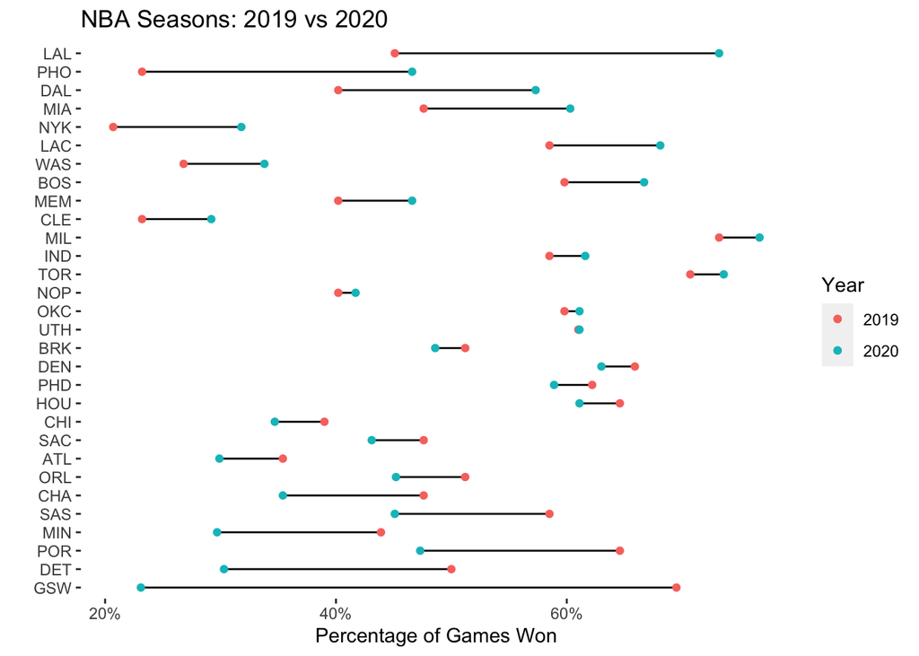

```r
dat %>%
  ggplot()+
  geom_segment(aes(x=PCT19, xend=PCT20,
                   y=reorder(AKA, diff_pct), yend=reorder(AKA, diff_pct)))+
  geom_point(aes(x=PCT19, y=AKA, col='2019'))+
  geom_point(aes(x=PCT20, y=AKA, col='2020'))+
  scale_x_continuous(labels = percent)+
  labs(title='NBA Seasons: 2019 vs 2020',
       x='Percentage of Games Won', y='',
       col='Year')+
  theme(panel.background = element_blank(),
        legend.background = element_blank())
```

A better alternative in this case is to use an arrow chart. I simply commented out `geom_point` call for the 2020 season, removed the color attribute altogether, and added an arrow to the `geom_segment`. I’ll also put the x-axis at the top and changed the titles.

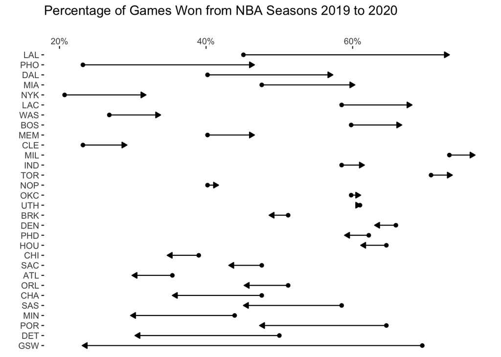

```r
dat %>%
  ggplot()+
  geom_segment(arrow = arrow(length=unit(0.20,"cm"), ends="last", type = "closed"),
               aes(x=PCT19, xend=PCT20,
                   y=reorder(AKA, diff_pct), yend=reorder(AKA, diff_pct)))+
  geom_point(aes(x=PCT19, y=AKA))+
  #geom_point(aes(x=PCT20, y=AKA, col='2020'))+
  scale_x_continuous(labels = percent, position = 'top')+
  labs(title='Percentage of Games Won from NBA Seasons 2019 to 2020',
       x='', y='',
       col='Year')+
  theme(panel.background = element_blank())
```

This plot better depicts the change in performance. It shows teams that had major improvements (LAL, PHO, DAL, MIA) as well as teams that had large declines (SAS, MIN, POR, DET, and GSW). The GSW don’t really stand out as the highlight. We could add annotations, color, a caption, etc. However, I think these are better suited in the plots of the ranks.

### Second Method - Change in Ranking from the 2019 - 2020 Seasons

Since a seed lower in numerical value is better than one with a higher value (first seed is better than second; second is better than third, and so on), this meant using the pure numerical value of the seed would indicate an upward line, and might convey stronger performance. This is why I used `factor` earlier. I added emphasis to Golden State’s decline by adding an arrow from their 2019 ranking to their 2020 ranking.

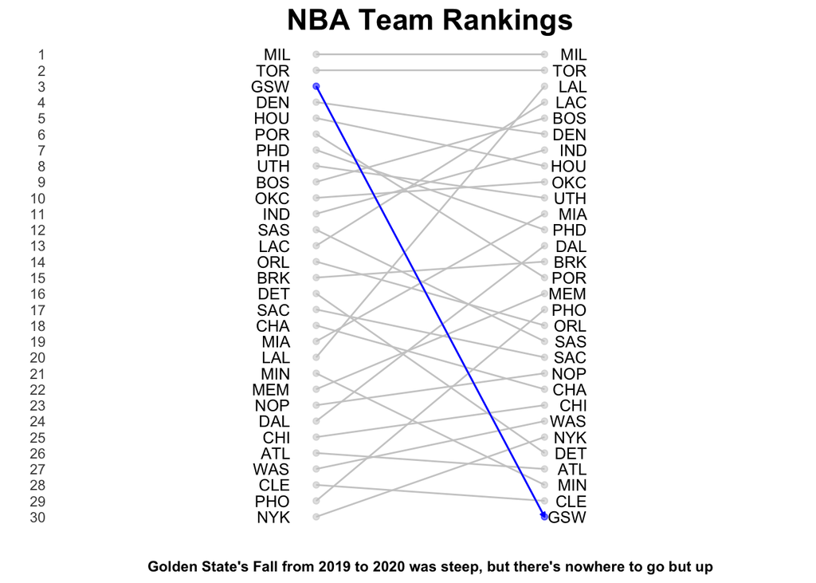

```r
cpt <- "Golden State's Fall from 2019 to 2020 was steep, but there's nowhere to go but up"

plt <-
  dat %>%
  ggplot()+
  geom_segment(aes(x=1, xend=2, y=rank19, yend=rank20,  col=is_gsw)) +
  xlim(0, 3)+
  geom_text(label=dat$AKA, x=rep(2.2, num_teams), y=dat$rank20, hjust=1.1, size=3.5)+
  geom_text(label=dat$AKA, x=rep(0.9, num_teams), y=dat$rank19, hjust=1.1, size=3.5)+
  geom_point(aes(x=rep(1, num_teams), y=rank19, alpha=0.1, fill=is_gsw, col=is_gsw))+
  geom_point(aes(x=rep(2, num_teams), y=rank20, alpha=0.1, fill=is_gsw, col=is_gsw))+
  geom_segment(data=filter(dat, is_gsw),
               aes(x=1, xend=2, y=rank19, yend=rank20),
               arrow = arrow(length=unit(0.10,"cm"), ends="last", type = "closed"),
               col=I('#0000ff'))+
  scale_color_manual(values = c('#cccccc', '#0000ff'))+
  scale_fill_manual(values = c('#cccccc', '#0000ff'))+
  labs(x='', y='', title='NBA Team Rankings',
        caption = cpt)+
  theme(panel.background = element_blank(),
        axis.ticks = element_blank(),
        axis.text.x = element_blank(),
        legend.position = 'none',
        plot.caption =  element_text(hjust = 0.5, size = 9, face='bold'),
        plot.title =  element_text(hjust=0.5, size = 18, face='bold'))

plt
```

Finally, I felt that it would be worthwhile to point out that the left is the 2019 season and the right is the 2020 season. I deleted the y-axis altogether since it’s apparent from the title that this is rankings, and the caption also adds to the story.

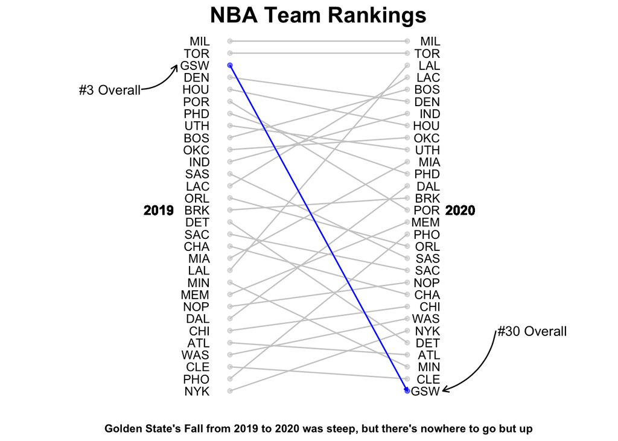

```r
plt +
  geom_text(x=0.6, y=team_rank(15), label="2019", fontface='bold',
            col='black')+
  geom_text(x=2.3, y=team_rank(15), label="2020", fontface='bold',
            col='black')+
  annotate(geom='curve', x=0.5, xend=0.7, y=team_rank(5), yend=team_rank(3),
           curvature = 0.3, arrow = arrow(length = unit(2, "mm")))+
  annotate(geom = "text", x = 0.15, y = team_rank(5),
           label = "#3 Overall", hjust = "left")+
  annotate(geom='curve', x=2.5, xend=2.2, y=team_rank(25), yend=team_rank(30),
           curvature = -0.3, arrow = arrow(length = unit(2, "mm")))+
  annotate(geom = "text", x = 2.51, y = team_rank(25),
           label = "#30 Overall", hjust = "left")+
  theme(axis.text.y = element_blank())
```